# Molecular descriptors of drug compounds: a digital way to describe drugs

## by Spencer Trinh

## Investigation Overview

> Exploration of physico-chemical properties and logistical characteristics of drug compounds in the ChEMBL dataset. Dataset extracted from Google BigQuery

## Dataset Overview

> ChEMBL Data is a manually curated database of small molecules used in drug discovery, including information about existing patented drugs

[figure not shown]

## Distribution and Barplot of full molecular weight, QED scores, molecule type and country of origin

> The first row shows a distribution plot of the molecular weight and QED scores, the atomic weight and the drug-likeness character (on scale of 0-1), respectively. Even if a log transformation was done for the molecular weight, there would be a huge gap in between because drug compounds above 1000 daltons is very rare. So no transformation was done. Most compounds in this dataset have a molecular weight in the range of 270-350 daltons. The QED distribution plot shows that most compounds in this dataset have a QED score of around 0.6. The first barplot shows most compounds in this dataset are considered small molecule which reflects what is seen in the first distribution plot that majority of compounds are about 270-350 daltons in weight. The last subplot shows the US have developed the most drugs in this dataset.

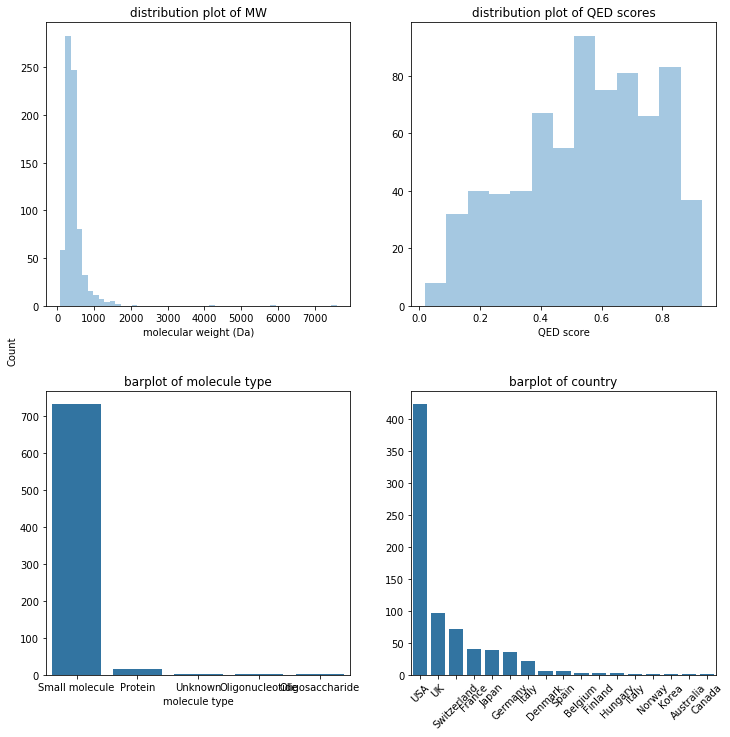

```python
f, axes = plt.subplots(2, 2, figsize=(12, 12))
pal = sns.color_palette()

# first subplot
c = 'full_mwt'
p = sns.distplot(dfm[c].values, kde=False, ax=axes[0,0])
p.set_xlabel('molecular weight (Da)')
p.set_title('distribution plot of MW')

# second subplot
c = 'qed_weighted'
p = sns.distplot(dfm[c].values, kde=False, ax=axes[0,1])
p.set_xlabel('QED score')
p.set_title('distribution plot of QED scores')

# third subplot
molec_type = dfm['molecule_type'].value_counts()
p = sns.barplot(x = molec_type.index,\
                y = molec_type.values,\
                color=pal[0],\
                ax=axes[1,0])
p.set_xlabel('molecule type')
p.set_title('barplot of molecule type')

# fourth subplot
countries = dfm['country'].value_counts()
p = sns.barplot(x = countries.index,\
                y= countries.values,\
                color=pal[0],\
                ax = axes[1,1])
p.set_xticklabels(countries.index, rotation=45);
p.set_title('barplot of country')

f.subplots_adjust(hspace=0.3)
f.text(0.08, 0.5, 'Count', va='center', rotation='vertical');
```